# newbie_workshop

chroneru

2018/4/24

# 自己紹介

- @chroneru_mineru
- R歴はぎゅっとすると2年ぐらい
- Rについてのブログを書いてる

# 1.Rのインストール

## 1.1.windows

- [Rのページ](https://www.r-project.org/)に行きます。
- Mirrors からjapanのミラーサイトを選択してください。
- Download R x.x.x for Windowsをクリックしてダウンロードして実行する。(x.x.xはバージョンです。)
- 後はインストーラにしたがってください。

## 1.2.mac

- homebrewでのインストールだとこんな感じ

```bash
brew tap homebrew/science
brew install r
```

## 1.3.linux

- 簡易的な方法を示します。
- ubuntu

```bash
sudo apt-get install r-base
```

- centos

```bash
sudo yum install epel-release
sudo yum --enablerepo=epel install R
```

# 2.Rstudioのインストール

## 2.1.windows

- [Rstudio](https://www.rstudio.com)のページからダウンロード，インストールします。
- 別に難しくない

## 2.2.mac

- homebrewでのインストール
  - brew-cask必須！

```bash
brew cask install rstudio
```

## 2.3.linux

- ubuntu

```bash
wget https://download1.rstudio.org/rstudio-1.1.447-amd64.deb
sudo dpkg -i rstudio-1.1.447-amd64.deb
```

- centos

```bash
sudo yum install wget
wget https://download2.rstudio.org/rstudio-server-rhel-1.1.442-x86_64.rpm
sudo yum install rstudio-server-rhel-1.1.442-x86_64.rpm
```

# 3.Rの演算子

## 3.1.算術演算子

- ふつうの計算に使う

| 演算子 | 使い方 | 結果 |
| --- | --- | --- |
| `+` | `1 + 2` | 3 |
| `-` | `1 - 2` | -1 |
| `*` | `2 * 3` | 6 |
| `/` | `2 / 3` | 0.6666667 |
| `^` | `2 ^ 3` | 8 |

## 3.2.代入演算子

- 代入に使う
- `=` は非推奨，`<-` を使う
- `<<-` はグローバル環境への代入
  - `<<-`よりもassign関数を使うほうがいい

| 演算子 | 使い方 |
| --- | --- |
| `<-` | `a <- 3` |
| `<<-` | `a <<- 5` |

# 4.データ型

## 4.1.ベクトル

- Rではベクトルとして代入される。
- 文字列は`""`でくくる。
- 数値はそのまま代入
- 論理値は`TRUE`と`FALSE`

```r
hoge <- "やっほー"
fuga <- 1.414
foo <- TRUE
hoge; fuga; foo
```

```
#> [1] "やっほー"
#> [1] 1.414
#> [1] TRUE
```

- 複数の値を代入するときは`c()`を使う
  - 型強制が起こる
    - 数値は文字列に
    - 論理値は数値か文字列に

```r
hoge <- c("やっほー", "おっはー")
fuga <- c(1.414, 1.732)
foo <- c(TRUE,FALSE)
hoge; fuga; foo
```

```
#> [1] "やっほー" "おっはー"
#> [1] 1.414 1.732
#> [1]  TRUE FALSE
```

```r
hoge2 <- c("やっほー", 1, TRUE)
fuga2 <- c(1.414, TRUE)
hoge2; fuga2
```

```
#> [1] "やっほー" "1"        "TRUE"
#> [1] 1.414 1.000
```

## クイズ

### 次のベクトルはどんなデータになるでしょう

```r
quiz1 <- c(1+TRUE, "やっほー")
quiz2 <- c(1+TRUE, 3) * FALSE
```

### 正解は

```r
quiz1
```

```
#> [1] "2"        "やっほー"
```

```r
quiz2
```

```
#> [1] 0 0
```

`TRUE`は`1`に，`FALSE`は`0`になります。

## 4.1.1.リサイクルルール

- 小さいベクトルが，大きいベクトルにあわせて繰り返されます。
- ベクトルの長さによって警告が出る

```r
a <- c(1,2,3,4)
b <- c(1,2)
c <- c(1,2,3)
```

```r
a * 3
```

```
#> [1]  3  6  9 12
```

```r
a + b
```

```
#> [1] 2 4 4 6
```

```r
b + a
```

```
#> [1] 2 4 4 6
```

```r
a * c
```

[output not shown]

## 4.1.2.ベクトルの要素を参照する

### ベクトルの要素は`[1]`からはじまる!

- ベクトルの参照は線形代数と一緒
- `[行番号,列番号]`で参照する!

```r
a <- c(1,2,3,4)
dim(a) <- c(2,2) #2次元配列
a
```

```
#>      [,1] [,2]
#> [1,]    1    3
#> [2,]    2    4
```

```r
a[1,2]
```

```
#> [1] 3
```

```r
a[c(1,2),2]
```

```
#> [1] 3 4
```

- 代入もできる

```r
a
```

```
#>      [,1] [,2]
#> [1,]    1    3
#> [2,]    2    4
```

```r
tmp <- a[2,1]
a[2,1] <- a[1,2]
a[1,2] <- tmp
a
```

```
#>      [,1] [,2]
#> [1,]    1    2
#> [2,]    3    4
```

## 4.2.NA

- `NA`はNot Available
- なにかわからない値に使う
- 特別な値

```r
na_vec <- c(NA, NA, NA)
is.na(na_vec)
```

```
#> [1] TRUE TRUE TRUE
```

```r
na_vec + 1
```

```
#> [1] NA NA NA
```

```r
na_vec == 1
```

```
#> [1] NA NA NA
```

```r
na_vec == NA
```

```
#> [1] NA NA NA
```

```r
na_vec != NA
```

```
#> [1] NA NA NA
```

## 4.3.scanfみたいなのも用意されてる

- readline関数

```r
a <- readline("入力してね: ")
```

```
#> 入力してね: ここに入力
```

- これを使うと簡単なクイズができる。

### 作ってみよう。

```r
quiz <- function() {
  answer <- "さくらんぼ"
  ans_u <- readline("おうとうってなんだ？: ")
  if (ans_u == answer) print("あってるよ")
  else print("まちがってるよ")
}
quiz()
```

```
#> [1] "まちがってるよ"
```

# 5.他言語との連携

# 5.1.C言語

- さっきのクイズをCにしてみると

```c
#include "/usr/include/stdio.h"
#include "/usr/include/stdlib.h"
#include "/usr/include/string.h"
#include "/usr/include/R/R.h"

void quiz(char **ans_u);

void quiz(char **ans_u) {
  char answer[] = "さくらんぼ";
  char yes[] = "あってるよ";
  char no[] = "まちがってるよ";

  printf("おうとうってなんだ？: %p\n",*ans_u);
  if(strcmp(answer,*ans_u) == 0) {
        printf("%s",yes);
  } else {
        printf("%s",no);
  }
}
```

- gccだとエラーは出ないが，危険っぽい

```bash
gcc -shared -fPIC -I/usr/include/R -o quiz_point.so quiz_point.c
```

- Rのバッチコマンドからビルドする

```bash
R CMD SHLIB quiz_point.c
```

```r
dyn.load("./C/quiz_point.so")
ANS <- "さくらんぼ"
.C('quiz', as.character(ANS))
```

[output not shown]

```r
dyn.unload("./C/quiz_point.so")
```

- `R.h`のinclude必要!
- ヘッダファイルのincludeには絶対パスで指定するのが簡単
- `?.C`でデータ型を確認する
- gccも使える
  - gccのオプションでヘッダファイルのパスを指定する。
    - `-I/usr/include/R`
    - R.h内部でRconfig.hが呼び出されるため

## 5.1.1.Cのコードはめんどい

- 関数の戻り値は`void`にする。
- 引数はポインタを使う。
- RのデータとCの引数の型とが一致しない
- gccだと.soをつくれてしまう
- Rバッチだとエラーの特定がしづらい

## 5.1.2.Rからロード

- 形式は，`.so`か`.dll`
- `dyn.load(`“hoge.so”`)`で読み込む
- `dyn.unload(`“hoge.so”`)`でアンロード
  - Rはメモリだけで処理するのでアンロードしておくといい
  - fcloseぐらいに思っておく
- `.C('関数名',引数)`か`.Call()`を使う
- RにはC用のデータ型が用意されている

# 5.2.シェルスクリプト

## 5.2.1.シェルスクリプト

- シェルでも再現してみる。
- これはけっこう素直に扱える。

```bash
#!/bin/sh

if [ $# -eq 1 ]
then
        echo "おうとうってなんだ？"
        R --vanilla --no-save --slave -f ./quiz_sh.R --args $1

else
        echo "引数の数が正しくありません。"
fi
```

```r
ans_u <- commandArgs(trailingOnly = TRUE)

diagnosis <- c("まちがってるよ\n",
               "あってるよ\n")

cat( ans_u )
cat( "\n" )

cat(diagnosis[ (ans_u == "さくらんぼ") + 1 ])
```

```bash
chmod u+x quiz_sh.sh
```

## 5.2.2.commandArgs()

- `trailingOnly = TRUE`を指定する。
  - `FALSE`だとコマンドとオプションも渡される。
- Rコマンドのオプションに`--args`を指定する。
- 引数を複数わたすこともできる。

## 5.2.3.shebang

- シバンを変えることで`.R`スクリプトを直接実行できる。

```bash
#! /usr/bin/R --vanilla --no-save --slave -f

quiz <- function() {
  answer <- "さくらんぼ"
  ans_u <- readline("おうとうってなんだ？: ")
  if (ans_u == answer) print("あってるよ")
  else print("まちがってるよ")
}
quiz()
```

```bash
chmod u+x ファイル名
```

## 5.2.4.ヒアドキュメント

- シェルのヒアドキュメントも使える

```bash
R --vanilla --no-save --slave << EOF
quiz <- function() {
  answer <- "さくらんぼ"
  ans_u <- readline("おうとうってなんだ？: ")
  if (ans_u == answer) print("あってるよ")
  else print("まちがってるよ")
}
quiz()
EOF
```

[output not shown]

## 6.1.2.ヒアドキュメント

- ヒアドキュメントでログをとる。
- インストール失敗時にべんり!
- windowsは使えない。

```bash
R --no-save << EOF > logfile 2>&1
install.packages("パッケージ名")
EOF
```

[output not shown]

- インストール時につまづきやすい
- エラーを読むと解決する

## 6.3.tidyverseの実践

- ggplotについての例を示す
- tidyverseパッケージが必要
- ggplot2でもOK

```r
library(tidyverse)
```

## 6.3.1.ggplot

- グラフをつくる関数
- レイヤーを重ねる
- 階層グラフィックス文法っていう書き方
- `geom`関数でプロットの形式を変えれる
- `ggsave()`で簡単にプロットを保存できる

とりあえずここまでにしておく。

```r
mtcars_tibble <- as_tibble(mtcars)
ggplot(
  data = mtcars_tibble,
  mapping = aes(
    x = mpg,
    y = disp,
    color = cyl
    )
  ) +
  geom_point()
```

- tibbleという型をつかう
- `+`で関数をつなぐ

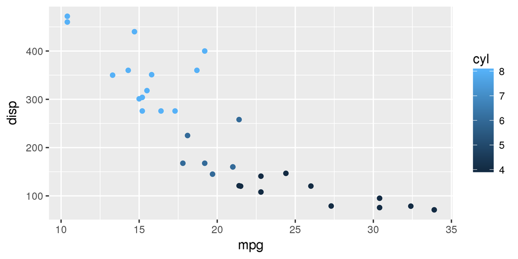

mtcars_tibble

# 7.関数

## 7.1.function()

- `function()`をつかう。
- ()のなかに引数をあたえる。
- 中のプログラムは`{}`でくくる。

## 7.2.関数例:パレート図の統計量

### あんまりよくない

- 個数を数える
- 大きいものからならべる(desc)
- 一個前のを自身に足す
- 割合を計算する

```r
pareto_func <- function(vec) {

res_count <- c("a" = NA, "b" = NA, "c" = NA, "d" = NA, "e" = NA)
for(moji in c("a", "b", "c", "d", "e")) {
    res_count[moji] <- sum(vec == moji)
}
res_count <- sort(res_count, decreasing = TRUE)
res_pareto <- cumsum(res_count)
res_pareto <- res_pareto / res_pareto[5]
list("count" = res_count, "density" = res_pareto)
}
```

- 一般化していない
- あとでつかってみます
- 引数は，仮引数
  - `function(a = 5)`のようにデフォルトも設定できる
- `c("a" = NA)`で名前を与えられる。
  - `names(ベクトル)`で名前を確認できる。
- `sort()`はならべかえ
- `cumsum()`は累積和

```r
cumsum( c(1, 2, 3, 4, 5))
```

```
#> [1]  1  3  6 10 15
```

# 8.データ

## 8.1.1.read.csv

- 標準で使える読み込み関数
- `stringAsFactors = FALSE`にする
  - 文字列が変化するのを防ぐ

```r
read.csv("ファイル名", stringAsFactors = FALSE)
```

## 8.1.2.read_csv

- tidyverse群に用意されてる関数(readr)

```r
read_csv(
  "ファイル名",
  locale = locale(encoding = "エンコード")
)
```

## 8.2.write.csv

- 標準のcsv作成関数
- `row.names = FALSE`
  - 行名が追加されるのを防ぐ

## 8.3.サンプルデータの作成

- Rにはさまざまなデータ作成関数がある
- `sample()`
- `runif()`
- `rnorm()`
- `rgamma()`

## 8.3.1.sample

- `sample()`で単純なデータを作成できる
- `size`は何個とりだすか
- `replace`は複数回とりだせるか
- `prob`は確率を指定する。
  - 合計が1じゃなくても大丈夫

```r
sample(1:100, size = 2)
```

```
#> [1] 33 78
```

## 8.3.2.その他

| 関数 | 確率分布 | 使い方 |
| --- | --- | --- |
| `runif()` | 一様分布 | `runif(5)` |
| `rnorm()` | 正規分布 | `rnorm(5)` |
| `rgamma()` | ガンマ分布 | `rgamma(5,shape = 2, rate = 5)` |
| `rbeta()` | ベータ分布 | `rbeta(5, shape1 = 0.5, shape2 = 0.5)` |

- shapeはk, rateはシータ
- shape1はα, shape2はβ

# 9.使用例

## 9.1.パレート図

```r
prob_vec <- sample(1:5, size = 5)
vec1 <- sample(
  1:5,
  size = 10000,
  replace = TRUE,
  prob = prob_vec
)
replace_abcde <- function(vec1) {
  num <- 1
  for(moji in c("a", "b", "c", "d", "e")) {
    vec1[vec1 == num] <- moji
    num <- num + 1
  }
  assign("vec1", vec1, envir = parent.env(environment()))
}
replace_abcde(vec1)
result <- pareto_func(vec1)
result
```

```
#> $count
#>    c    e    b    a    d
#> 3341 2677 1972 1322  688
#>
#> $density
#>      c      e      b      a      d
#> 0.3341 0.6018 0.7990 0.9312 1.0000
```

- 図にすると

```r
result <- as_tibble(result) %>%
  mutate(
    name = names(result$count),
    count_density = count / sum(count)
  )
```

```r
result %>%
  ggplot() +
  geom_hline(
    yintercept = c(0.7,0.9,1),
    size = 0.2,
    color = "#ff0000"
  ) +
  geom_bar(
    aes(name, count_density, fill = density),
    stat = "identity"
  ) +
  geom_line(aes(name, density, group ="1")) +
  geom_point(
    aes(name, density, color = density),
    size = 5
  ) +
  scale_x_discrete(limits = result$name) +
  scale_y_continuous(breaks = seq(0, 1, by = 0.1)) +
  scale_color_gradient(low = "#006600", high = "#ccffcc") +
  scale_fill_gradient(low = "#006600", high = "#ccffcc") +
#  viridis::scale_fill_viridis(option="inferno") +
#  viridis::scale_color_viridis() +
  coord_cartesian(ylim = c(0,1)) +
  labs(
    x = names(result$count),
    y = NULL
    ) +
  theme(legend.position = "none")

# ggsave("pareto_graph.png")
```

見やすい方

[figure not shown]

# 10.統計処理

## 10.1.とりあえずやってみる。

- `ToothGrowth`というデータセットを使ってみる

```r
head(ToothGrowth)
```

```
#>    len supp dose
#> 1  4.2   VC  0.5
#> 2 11.5   VC  0.5
#> 3  7.3   VC  0.5
#> 4  5.8   VC  0.5
#> 5  6.4   VC  0.5
#> 6 10.0   VC  0.5
```

```r
class(ToothGrowth)
```

```
#> [1] "data.frame"
```

- モルモットの歯のデータセット
  - `VC`かオレンジジュース(`Oj`)の用量と歯の長さ

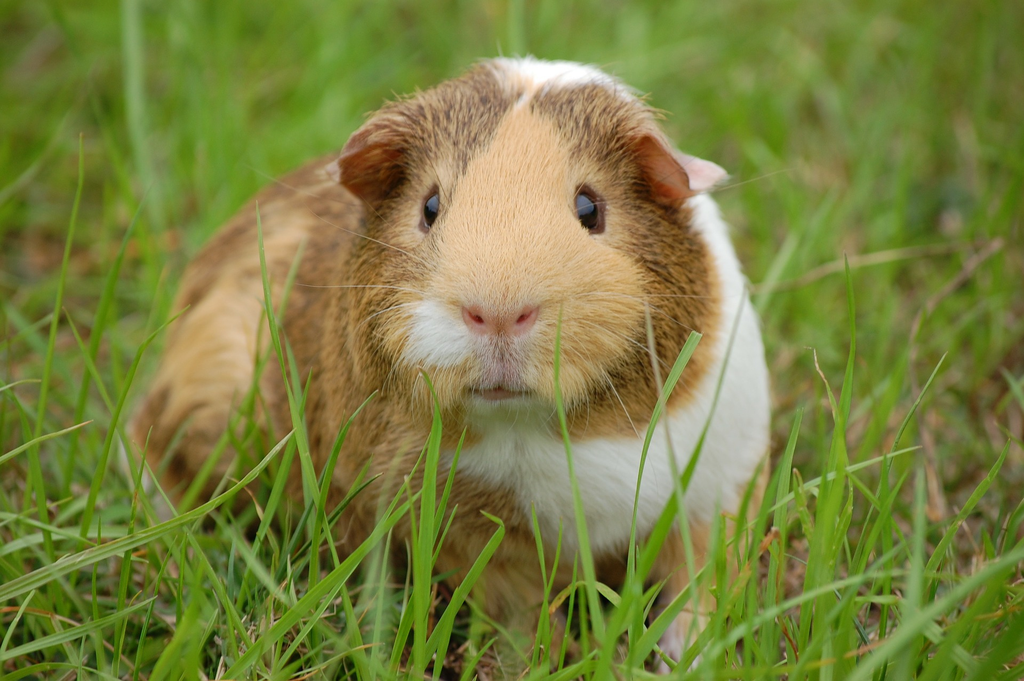

## 10.1.1.方針

1. tidyverse群がつかえるようにtibbleにする。
2. 列名をわかりやすくする
3. とりあえず散布図を作る
4. 他の処理について考える

## 10.1.2.tibble型の威力

```r
ToothGrowth2 <- as_tibble(ToothGrowth)
ToothGrowth2 %>% head(2) %>% knitr::kable()
```

| len | supp | dose |
| --- | --- | --- |
| 4.2 | VC | 0.5 |
| 11.5 | VC | 0.5 |

```r
ToothGrowth2 %>% tail(2) %>% knitr::kable()
```

| len | supp | dose |
| --- | --- | --- |
| 29.4 | OJ | 2 |
| 23.0 | OJ | 2 |

## 10.1.3.列名を変更する

- ここは参考ぐらいに

```r
names(ToothGrowth2) <- c("Tooth_length", "Supplement", "Dose")
ToothGrowth2 %>% head() %>% knitr::kable()
```

| Tooth_length | Supplement | Dose |
| --- | --- | --- |
| 4.2 | VC | 0.5 |
| 11.5 | VC | 0.5 |
| 7.3 | VC | 0.5 |
| 5.8 | VC | 0.5 |
| 6.4 | VC | 0.5 |
| 10.0 | VC | 0.5 |

## 10.1.4.散布図で様子見

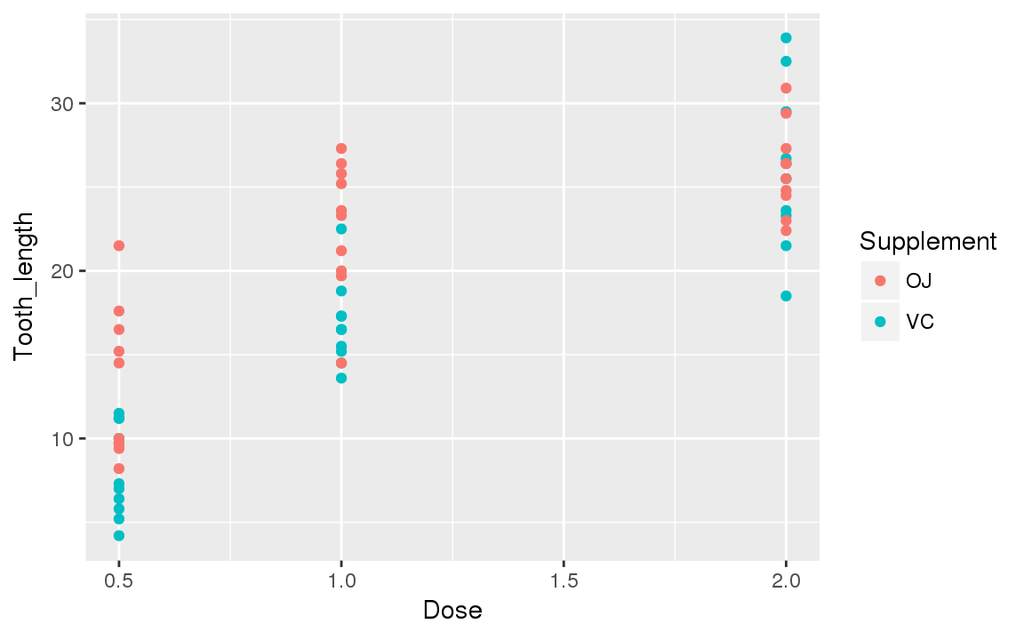

```r
ToothGrowth2 %>%
  ggplot(aes(Dose, Tooth_length, color = Supplement)) +
  geom_point()
```

## 10.1.5.線形回帰分析

- `lm()`を使う

```r
ToothGrowth2_VC_lm <- lm(Tooth_length ~ Dose, data = ToothGrowth2 %>% filter(Supplement == "VC"))
ToothGrowth2_OJ_lm <- lm(Tooth_length ~ Dose, data = ToothGrowth2 %>% filter(Supplement == "OJ"))
ToothGrowth2_lm <- list(VC_lm = summary(ToothGrowth2_VC_lm), OJ_lm = summary(ToothGrowth2_OJ_lm))
ToothGrowth2_lm$VC_lm$coefficients; ToothGrowth2_lm$OJ_lm$coefficients
```

```
#>             Estimate Std. Error   t value     Pr(>|t|)
#> (Intercept)  3.29500   1.427060  2.308943 2.854201e-02
#> Dose        11.71571   1.078756 10.860392 1.509369e-11
#>              Estimate Std. Error  t value     Pr(>|t|)
#> (Intercept) 11.550000   1.721951 6.707508 2.788784e-07
#> Dose         7.811429   1.301673 6.001070 1.824801e-06
```

```r
ToothGrowth2_lm$VC_lm$coefficients; ToothGrowth2_lm$VC_lm$coefficients
```

```
#>             Estimate Std. Error   t value     Pr(>|t|)
#> (Intercept)  3.29500   1.427060  2.308943 2.854201e-02
#> Dose        11.71571   1.078756 10.860392 1.509369e-11
#>             Estimate Std. Error   t value     Pr(>|t|)
#> (Intercept)  3.29500   1.427060  2.308943 2.854201e-02
#> Dose        11.71571   1.078756 10.860392 1.509369e-11
```

```r
# Tooth_length = 3.295 + 11.716 * Dose
# Tooth_length = 11.550 + 7.811 * Dose
```

- 回帰直線のプロット

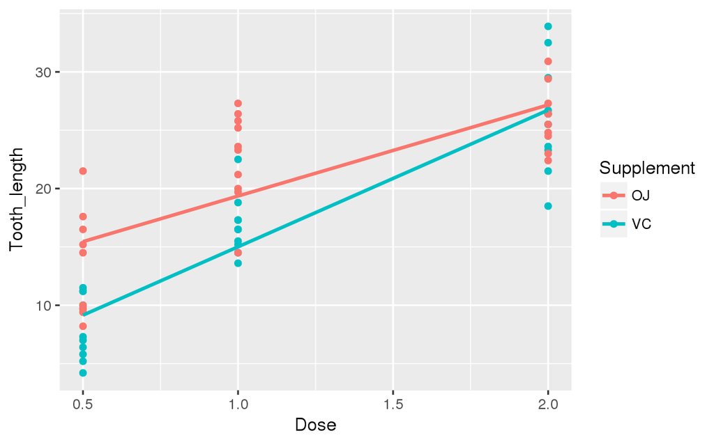

```r
ToothGrowth2 %>%
  group_by(Supplement) %>%
  ggplot(aes(Dose, Tooth_length, color = Supplement)) +
  geom_point() +
  geom_smooth(method = "lm", se = FALSE)
```

# 10.2.ベイズ

## 10.2.1.ベイズ統計

- ToothGrowthでは母集団が少ない。
- なにもしていない時の歯の増加量がわからない。
- 特に事前情報がない。

## そんなときはベイズ

## 10.2.2.baysian linear regression

- 要は線形回帰分析

```r
ToothGrowth2_VC_bayes_lm <- MCMCpack::MCMCregress(Tooth_length ~ Dose, ToothGrowth2 %>% filter(Supplement == "VC"), verbose = 10000)
```

```
#>
#>
#> MCMCregress iteration 1 of 11000
#> beta =
#>    5.47369
#>   10.64170
#> sigma2 =   15.77352
#>
#>
#> MCMCregress iteration 10001 of 11000
#> beta =
#>    4.01607
#>   11.34625
#> sigma2 =    9.06792
```

```r
ToothGrowth2_OJ_bayes_lm <- MCMCpack::MCMCregress(Tooth_length ~ Dose, ToothGrowth2 %>% filter(Supplement == "OJ"), verbose = 10000)
```

```
#>
#>
#> MCMCregress iteration 1 of 11000
#> beta =
#>   14.17890
#>    6.51548
#> sigma2 =   22.96599
#>
#>
#> MCMCregress iteration 10001 of 11000
#> beta =
#>   12.42007
#>    7.36562
#> sigma2 =   13.20275
```

```r
ToothGrowth2_bayes_lm <- list(VC_bayes_lm = summary(ToothGrowth2_VC_bayes_lm), OJ_bayes_lm = summary(ToothGrowth2_OJ_bayes_lm))
ToothGrowth2_bayes_lm
```

```
#> $VC_bayes_lm
#>
#> Iterations = 1001:11000
#> Thinning interval = 1
#> Number of chains = 1
#> Sample size per chain = 10000
#>
#> 1. Empirical mean and standard deviation for each variable,
#>    plus standard error of the mean:
#>
#>               Mean    SD Naive SE Time-series SE
#> (Intercept)  3.312 1.487  0.01487        0.01452
#> Dose        11.703 1.127  0.01127        0.01127
#> sigma2      14.662 4.276  0.04276        0.04573
#>
#> 2. Quantiles for each variable:
#>
#>               2.5%    25%    50%    75%  97.5%
#> (Intercept) 0.4164  2.353  3.325  4.267  6.278
#> Dose        9.4136 10.978 11.702 12.423 13.927
#> sigma2      8.5478 11.647 13.928 16.818 24.859
#>
#>
#> $OJ_bayes_lm
#>
#> Iterations = 1001:11000
#> Thinning interval = 1
#> Number of chains = 1
#> Sample size per chain = 10000
#>
#> 1. Empirical mean and standard deviation for each variable,
#>    plus standard error of the mean:
#>
#>               Mean    SD Naive SE Time-series SE
#> (Intercept) 11.571 1.794  0.01794        0.01752
#> Dose         7.796 1.360  0.01360        0.01360
#> sigma2      21.347 6.226  0.06226        0.06658
#>
#> 2. Quantiles for each variable:
#>
#>               2.5%    25%    50%    75% 97.5%
#> (Intercept)  8.077 10.413 11.586 12.723 15.15
#> Dose         5.034  6.922  7.795  8.665 10.48
#> sigma2      12.445 16.958 20.279 24.486 36.19
```

```r
Intercept <- c(ToothGrowth2_bayes_lm$VC_bayes_lm$statistics[1,1],
                ToothGrowth2_bayes_lm$OJ_bayes_lm$statistics[1,1])
slope <- c(ToothGrowth2_bayes_lm$VC_bayes_lm$statistics[2,1],
                ToothGrowth2_bayes_lm$OJ_bayes_lm$statistics[2,1])
Intercept; slope
```

```
#> [1]  3.312116 11.570653
#> [1] 11.703262  7.796404
```

```r
ToothGrowth2 %>%
  group_by(Supplement) %>%
  ggplot(aes(Dose, Tooth_length, color = Supplement)) +
  geom_point() +
  geom_smooth(method = "lm", se = FALSE, size = 2) +
  stat_function(
    fun = function(Dose)  Intercept[1] + slope[1] * Dose,
    geom = "line",
    color = "#00ffc4",
    size = 0.6,
    xlim = c(0.5, 2.0),
    show.legend = TRUE
  ) +
  stat_function(
    fun = function(Dose) Intercept[2] + slope[2] * Dose,
    geom = "line",
    color = "#ffe4f1",
    size = 0.5,
    xlim = c(0.5, 2.0),
    show.legend = TRUE
  )
```

## 10.2.3.MCMCregress

- `MCMCpack`パッケージを使う。
- `MCMCpack::MCMCregress`でMCMC法での回帰直線を作成する。
- デフォルトでバーンインは1000回,イテレーションは10000回
- verboseを設定すると進行状況と各変数の確率分布を`print`で表示できる。

MCMC法による線形回帰の結果を通常の線形回帰分析と重ねあわせてみると

- だいたいおなじ
- あくまで目安

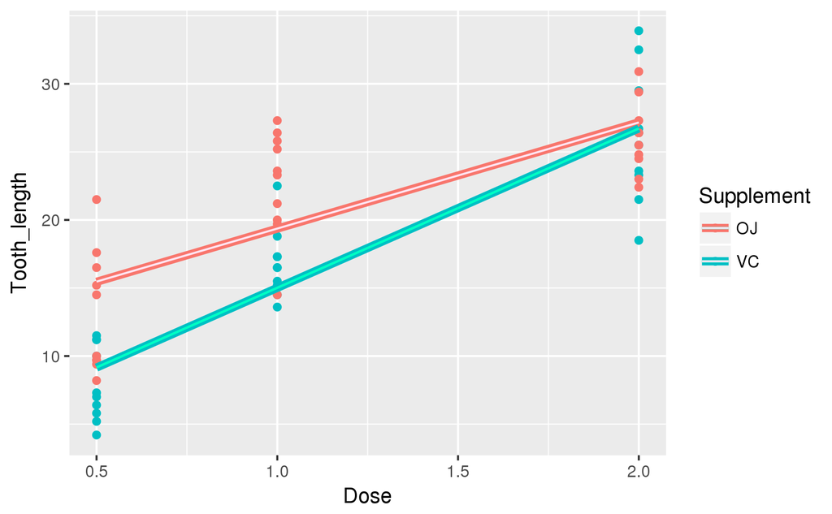